# Layering particle effects

The beam animates, but it lacks some punch. Let’s add particles on the firing point that look like sparkles.

[video not shown]

## Designing the cast particles

Select the *CastingParticles2D* and add a *Particles Material* to it.

We want the particles to move in the direction of the beam. Expand the material, expand the *Gravity* category, and set the `y` value to `0`.

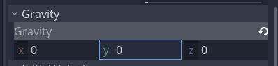

In the *Initial Velocity* category, drag the *Velocity* slider to about `100` pixels per second. You can click on the value to set it manually.

### Fading the particles

The particles disappear abruptly. We are now going to make them fade out and scale down.

Find the *Color* category and assign a new *Gradient* to the *Color Ramp* property. We’re going to use it to fade out the particles.

Change the left color stop to an opaque white and drag it to two-thirds of the Gradient. Change the right color stop to a transparent white.

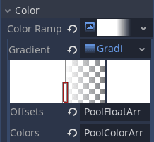

Under the *Scale* category, click on the *Scale* slot and set its value to `0.5` to decrease the particles’ default size.

Create a new Curve in the *Scale Curve* property. Drag the left point to about half of the curve’s horizontal axis and keep it at a value of `1` in the vertical axis.

Drag the rightmost point down to `0`.

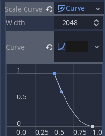

This scale curve makes the particles disappear more naturally.

[video not shown]

Finally, scroll back up the Inspector and toggle the *Emitting* property of the particle system off, so it doesn’t emit continuously.

## Adding particles along the beam

Let’s add particles that spawn along with the laser.

We’re going to use a box emission shape and change its extents to match the Beam’s length. We are also going to make the particles swirl.

[video not shown]

Select the *BeamParticles2D* node and head to the Inspector.

We want many particles, so set the *Amount* to `50`. We can randomize the time interval between two new particles increasing the *Randomness* to `1`.

In the *Material* property, create a new “ParticlesMaterial”. Change the *Gravity* and make sure it has a value of 0 in `x`, `y`, and `z` to prevent the particles from falling.

In the *Initial Velocity* category, change the *Velocity*’s `x` to `-100`. to make the particles move towards the left, moving them slowly towards the beam’s origin.

Now, to make the particles swirl around the beam, expand the *Tangential Acceleration* category and change the *Accel* to `100`. Drag the *Accel Random* up to `1` to randomize the effect.

Next, find the *Shape* property under the *Emission Shape* category and change it to “Box”. In the *Box Extents*, set the `y` value to `20`.

Let’s animate the particles to give them a more natural feel. Find the *Scale* property and change it to `0.3`. Create a new Curve in *Scale Curve*.

Drag both points in the scale curve to `0` on the vertical axis. Add a new point in the middle of the curve and drag it up to `1` vertically.

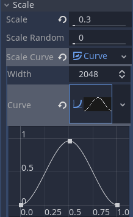

We have two more parameters to change on the particle system itself. Head back up out of the *ParticlesMaterial* and toggle off the *Local Coordinates* to keep the particles in place as the *LaserBeam2D* moves. Finally, change *Draw order* to “Life Time” to keep the newest particles on top of the older ones.

You should get a result looking like that:

[video not shown]

## Collision particles

Finally, let’s design the particles when the laser hits something. These particles are similar to the *CastingParticles2D*, so to be efficient, we are going to copy its material.

Select the *CastingParticles2D* node in the Scene tree. In the Inspector, right-click on the *Material* slot. From the drop-down menu, select the “Copy” option.

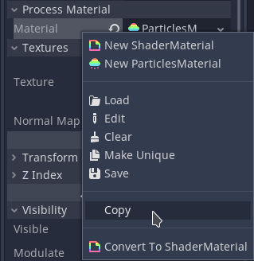

Select the *CollisionParticles2D* node. In the Inspector, right-click on the *Material* and select “Paste”.

From there, both *CastingParticles2D* and *CollisionParticles2D* are sharing the same *ParticlesMaterial* resource. They behave the same way, but changing the material on one node would apply the same change to the other. Sometimes, you want to share resources, but in our case, we do not.

To prevent that, we need to make the resource unique. Right-click on the *ParticlesMaterial* in the *Material* slot and from the drop-down menu, select “Make Unique”.

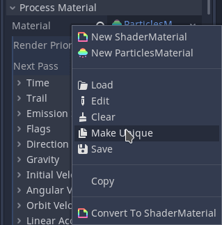

Now, we can modify the material of *CollisionParticles2D* without affecting that of *CastingParticles2D*. Let’s increase its *Initial Velocity* to make it spread more.

Increase the *Amount* property to `16` and set the particles’ *Lifetime* to `0.3`. Toggle off the *Local Coordinates* property, so the sparkles do not rotate with the laser. With that, you finished.

Here is the final result:

[video not shown]